# Supervised Learning in R

Waiyego Mburu

09/07/2021

## **DATA UNDERSTANDING**

To identify which kind of individuals(profiles) are most likely to click on ads related to an online cryptography course if it were advertised on a blog given data on a related course that was advertised on the same blog some time ago.

## **METRIC OF SUCCESS**

If we create a model that has a high accuracy in predicting which group of people are highly likely to click on adverts for an online cryptography course, the initiative will be a success. The ability to come up with the best fits for these initiatives will be critical to their success.

## **CONTEXT**

A Kenyan entrepreneur has created an online cryptography course and would want to advertise it on her blog. She currently targets audiences originating from various countries. In the past, she ran ads to advertise a related course on the same blog and collected data in the process. She would now like to employ your services as a Data Science Consultant to help her identify which individuals are most likely to click on her ads.

## **EXPERIMENTAL DESIGN**

- Import the relevant libraries that we will use in our analysis
- Read and explore the dataset we will use for our project
- Define the appropriateness of the available data with regards to the project
- Find and deal with outliers, anomalies, and missing data within the dataset.
- Perform univariate and bivariate analysis while recording our observations.
- Implementing the solution using various supervised machine learning algorithms
- Challenging the Solution
- Follow up Questions

## **DATA RELEVANCE**

Our dataset is very relevant since it has most of the factors considered before rolling out of an advert. These factors include age group, site, traffic on the site.

## **READING THE DATASET**

```r
advertising = read.csv("http://bit.ly/IPAdvertisingData")
```

##### Checking the first 6 entries

```r
head(advertising)
```

```
##   Daily.Time.Spent.on.Site Age Area.Income Daily.Internet.Usage
## 1                    68.95  35    61833.90               256.09
## 2                    80.23  31    68441.85               193.77
## 3                    69.47  26    59785.94               236.50
## 4                    74.15  29    54806.18               245.89
## 5                    68.37  35    73889.99               225.58
## 6                    59.99  23    59761.56               226.74
##                           Ad.Topic.Line           City Male    Country
## 1    Cloned 5thgeneration orchestration    Wrightburgh    0    Tunisia
## 2    Monitored national standardization      West Jodi    1      Nauru
## 3      Organic bottom-line service-desk       Davidton    0 San Marino
## 4 Triple-buffered reciprocal time-frame West Terrifurt    1      Italy
## 5         Robust logistical utilization   South Manuel    0    Iceland
## 6       Sharable client-driven software      Jamieberg    1     Norway
##             Timestamp Clicked.on.Ad
## 1 2016-03-27 00:53:11             0
## 2 2016-04-04 01:39:02             0
## 3 2016-03-13 20:35:42             0
## 4 2016-01-10 02:31:19             0
## 5 2016-06-03 03:36:18             0
## 6 2016-05-19 14:30:17             0
```

##### Checking the last 6 entries

```r
tail(advertising)
```

```
##      Daily.Time.Spent.on.Site Age Area.Income Daily.Internet.Usage
## 995                     43.70  28    63126.96               173.01
## 996                     72.97  30    71384.57               208.58
## 997                     51.30  45    67782.17               134.42
## 998                     51.63  51    42415.72               120.37
## 999                     55.55  19    41920.79               187.95
## 1000                    45.01  26    29875.80               178.35
##                             Ad.Topic.Line          City Male
## 995         Front-line bifurcated ability  Nicholasland    0
## 996         Fundamental modular algorithm     Duffystad    1
## 997       Grass-roots cohesive monitoring   New Darlene    1
## 998          Expanded intangible solution South Jessica    1
## 999  Proactive bandwidth-monitored policy   West Steven    0
## 1000      Virtual 5thgeneration emulation   Ronniemouth    0
##                     Country           Timestamp Clicked.on.Ad
## 995                 Mayotte 2016-04-04 03:57:48             1
## 996                 Lebanon 2016-02-11 21:49:00             1
## 997  Bosnia and Herzegovina 2016-04-22 02:07:01             1
## 998                Mongolia 2016-02-01 17:24:57             1
## 999               Guatemala 2016-03-24 02:35:54             0
## 1000                 Brazil 2016-06-03 21:43:21             1
```

##### Checking the shape of our dataset

```r
dim(advertising)
```

```
## [1] 1000   10
```

##### Checking for duplicates and unique values

```r
duplicates <- advertising[duplicated(advertising),]
duplicates
```

```
##  [1] Daily.Time.Spent.on.Site Age                      Area.Income
##  [4] Daily.Internet.Usage     Ad.Topic.Line            City
##  [7] Male                     Country                  Timestamp
## [10] Clicked.on.Ad
## <0 rows> (or 0-length row.names)
```

There are no duplicates in our dataset.

##### Getting information on our datatypes

```r
str(advertising)
```

```
## 'data.frame':    1000 obs. of  10 variables:
##  $ Daily.Time.Spent.on.Site: num  69 80.2 69.5 74.2 68.4 ...
##  $ Age                     : int  35 31 26 29 35 23 33 48 30 20 ...
##  $ Area.Income             : num  61834 68442 59786 54806 73890 ...
##  $ Daily.Internet.Usage    : num  256 194 236 246 226 ...
##  $ Ad.Topic.Line           : chr  "Cloned 5thgeneration orchestration" "Monitored national standardization" "Organic bottom-line service-desk" "Triple-buffered reciprocal time-frame" ...
##  $ City                    : chr  "Wrightburgh" "West Jodi" "Davidton" "West Terrifurt" ...
##  $ Male                    : int  0 1 0 1 0 1 0 1 1 1 ...
##  $ Country                 : chr  "Tunisia" "Nauru" "San Marino" "Italy" ...
##  $ Timestamp               : chr  "2016-03-27 00:53:11" "2016-04-04 01:39:02" "2016-03-13 20:35:42" "2016-01-10 02:31:19" ...
##  $ Clicked.on.Ad           : int  0 0 0 0 0 0 0 1 0 0 ...
```

## Checking for null values per column

```r
colSums(is.na(advertising))
```

```
## Daily.Time.Spent.on.Site                      Age              Area.Income
##                        0                        0                        0
##     Daily.Internet.Usage            Ad.Topic.Line                     City
##                        0                        0                        0
##                     Male                  Country                Timestamp
##                        0                        0                        0
##            Clicked.on.Ad
##                        0
```

Our dataset has no missing data hence is complete and of good quality.

## Checking for outliers in our numerical variables

```r
Time.onsite <- advertising$Daily.Time.Spent.on.Site
Age <- advertising$Age
Income <- advertising$Area.Income
Internet <- advertising$Daily.Internet.Usage
Topic <- advertising$Ad.Topic.Line
City <- advertising$City
Gender <- advertising$Male
Country <- advertising$Country
Clicked.on.Ad <- advertising$Clicked.on.Ad
```

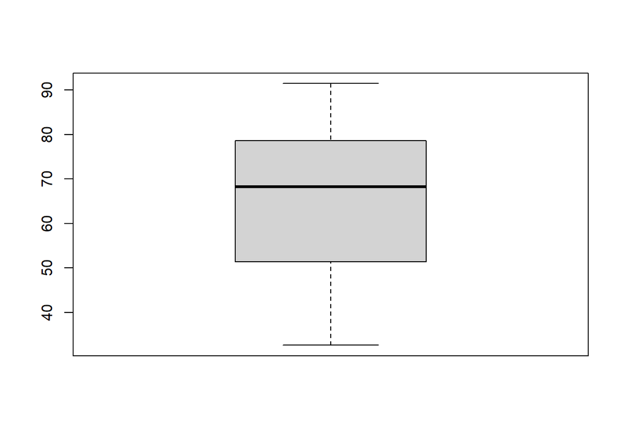

```r
boxplot(Time.onsite)
```

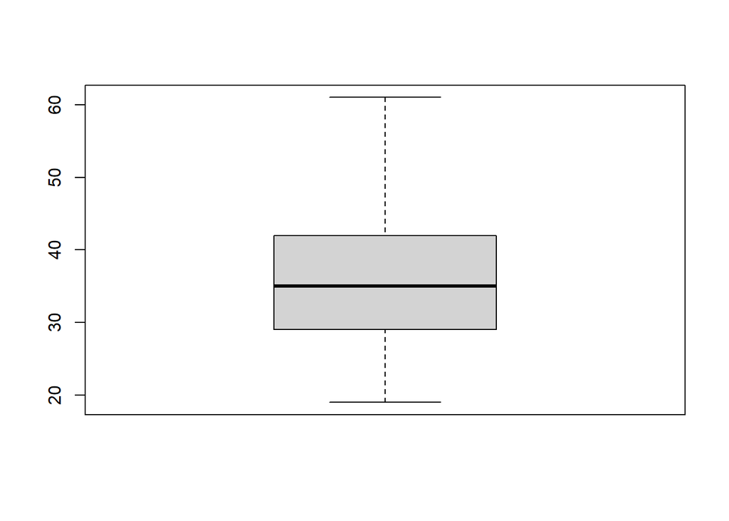

```r
boxplot(Age)
```

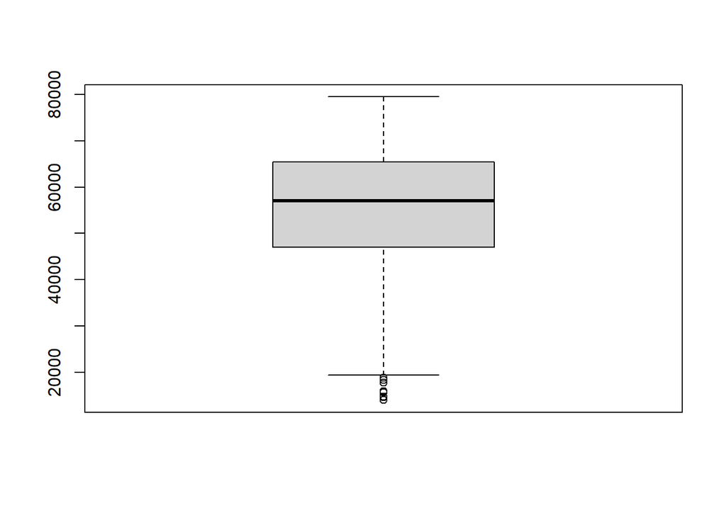

```r
boxplot(Income)
```

```r
boxplot.stats(Income)$out
```

```
## [1] 17709.98 18819.34 15598.29 15879.10 14548.06 13996.50 14775.50 18368.57
```

As can be seen the area income column has outliers. These outliers can be explained since there are other factors at play like demographics and varied income rates in different countries. Therefore, we do not remove the outliers.

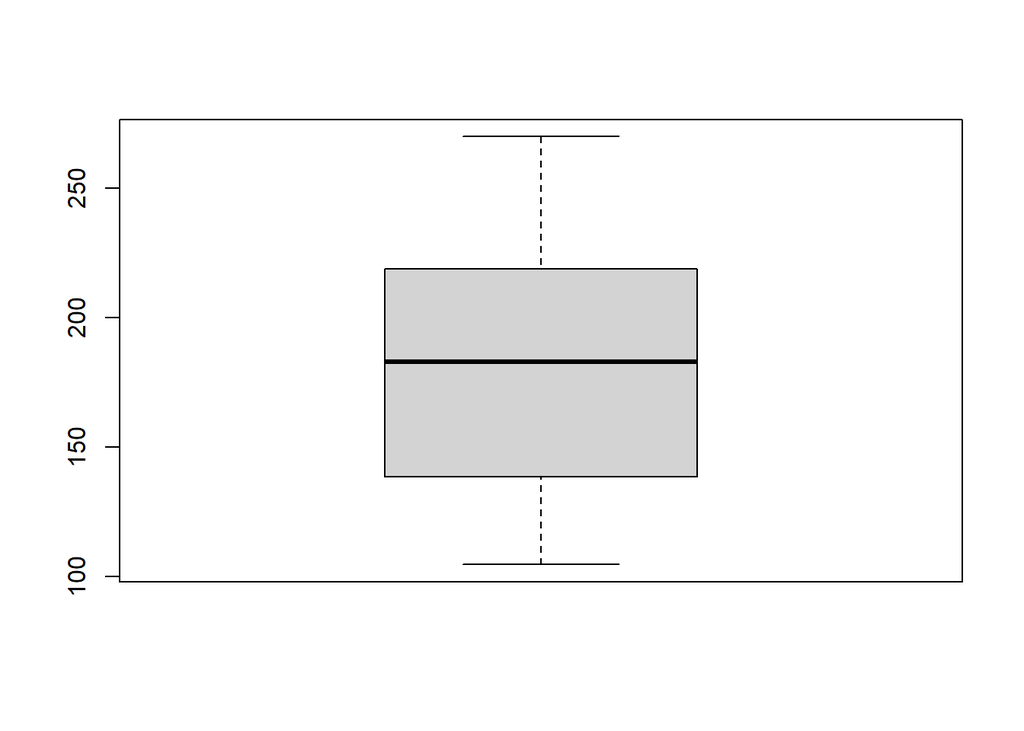

```r
boxplot(Internet)
```

## **Exploratory Data Analysis**

## Univariate Analysis

### Measures of central Tendency (mean ,median,mode)

#### **Mean**

```r
Time.onsite.mean = mean(Time.onsite)
Time.onsite.mean
```

```
## [1] 65.0002
```

```r
Age.mean = mean(Age)
Age.mean
```

```
## [1] 36.009
```

```r
Income.mean = mean(Income)
Income.mean
```

```
## [1] 55000
```

```r
Internet.mean = mean(Internet)
Internet.mean
```

```
## [1] 180.0001
```

#### **Mode**

```r
getmode = function(v){
   uniqv <- unique(v)
   uniqv[which.max(tabulate(match(v, uniqv)))]
}
```

```r
Time.onsite.mode = getmode(Time.onsite)
Time.onsite.mode
```

```
## [1] 62.26
```

```r
Age.mode = getmode(Age)
Age.mode
```

```
## [1] 31
```

```r
Income.mode = getmode(Income)
Income.mode
```

```
## [1] 61833.9
```

```r
Internet.mode = getmode(Internet)
Internet.mode
```

```
## [1] 167.22
```

```r
Country.mode = getmode(Country)
Country.mode
```

```
## [1] "Czech Republic"
```

```r
City.mode = getmode(City)
City.mode
```

```
## [1] "Lisamouth"
```

1. The most occurring age among our users is 31 years.
2. The City with the most repeat users is Lisamouth.
3. The country that’s most repeated is Czech Republic.
4. Most of our respondents were female.

#### **Median**

```r
Time.onsite.median = median(Time.onsite)
Time.onsite.median
```

```
## [1] 68.215
```

```r
Age.median = median(Age)
Age.median
```

```
## [1] 35
```

```r
Income.median = median(Income)
Income.median
```

```
## [1] 57012.3
```

```r
Internet.median = median(Internet)
Internet.median
```

```
## [1] 183.13
```

### Measures of dispersion(Variance, SD)

#### **Variance**

```r
Time.onsite.variance = var(Time.onsite)
Time.onsite.variance
```

```
## [1] 251.3371
```

```r
Age.variance = var(Age)
Age.variance
```

```
## [1] 77.18611
```

```r
Income.variance = var(Income)
Income.variance
```

```
## [1] 179952406
```

```r
Internet.variance = var(Internet)
Internet.variance
```

```
## [1] 1927.415
```

#### **Standard Deviation**

```r
Time.onsite.standard.deviation = sd(Time.onsite)
Time.onsite.standard.deviation
```

```
## [1] 15.85361
```

```r
Age.standard.deviation = sd(Age)
Age.standard.deviation
```

```
## [1] 8.785562
```

```r
Income.standard.deviation = sd(Income)
Income.standard.deviation
```

```
## [1] 13414.63
```

```r
Internet.standard.deviation = sd(Internet)
Internet.standard.deviation
```

```
## [1] 43.90234
```

### Range

```r
range(Time.onsite)
```

```
## [1] 32.60 91.43
```

```r
range(Age)
```

```
## [1] 19 61
```

```r
range(Income)
```

```
## [1] 13996.5 79484.8
```

```r
range(Internet)
```

```
## [1] 104.78 269.96
```

### Skewness and Kurtosis

#### **Skewness**

```r
# Load the e1071 library that allows us to compute skewness and kurtosis
library(e1071)
```

```r
Time.onsite.skew = skewness(Time.onsite)
Time.onsite.skew
```

```
## [1] -0.370646
```

```r
Age.skew = skewness(Age)
Age.skew
```

```
## [1] 0.4777052
```

```r
Income.skew = skewness(Income)
Income.skew
```

```
## [1] -0.6484229
```

```r
Internet.skew = skewness(Internet)
Internet.skew
```

```
## [1] -0.03343681
```

#### **Kurtosis**

```r
Time.onsite.kurt = kurtosis(Time.onsite)
Time.onsite.kurt
```

```
## [1] -1.099864
```

```r
Age.kurt = kurtosis(Age)
Age.kurt
```

```
## [1] -0.4097066
```

```r
Income.kurt = kurtosis(Income)
Income.kurt
```

```
## [1] -0.1110924
```

```r
Internet.kurt = kurtosis(Internet)
Internet.kurt
```

```
## [1] -1.275752
```

## Plotting Bar Charts of categorical variables

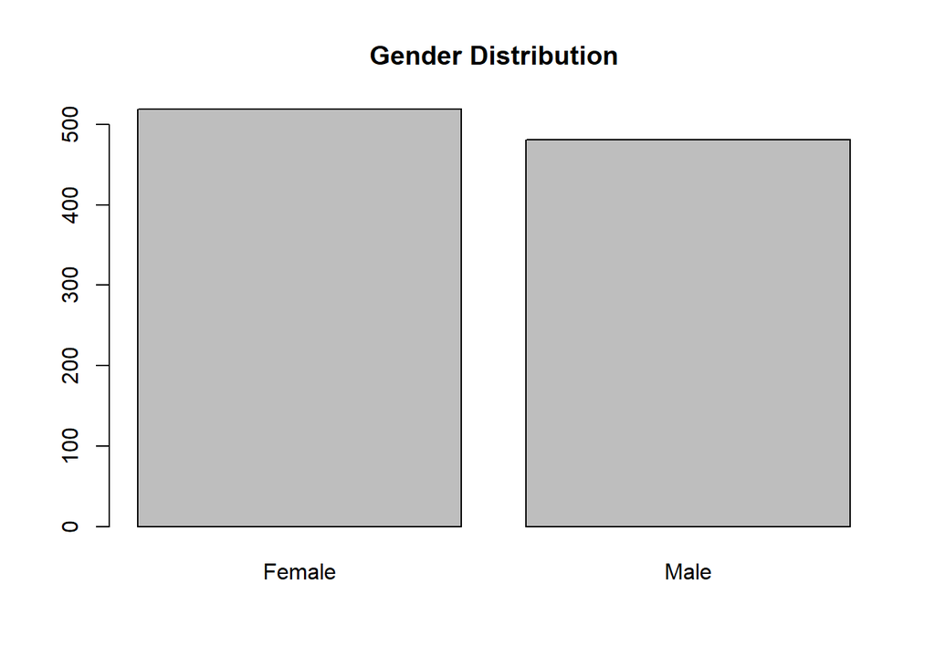

```r
Gender.distribution <- table(Gender)
label <- c("Female","Male")
barplot(Gender.distribution,names.arg = label,main = "Gender Distribution")
```

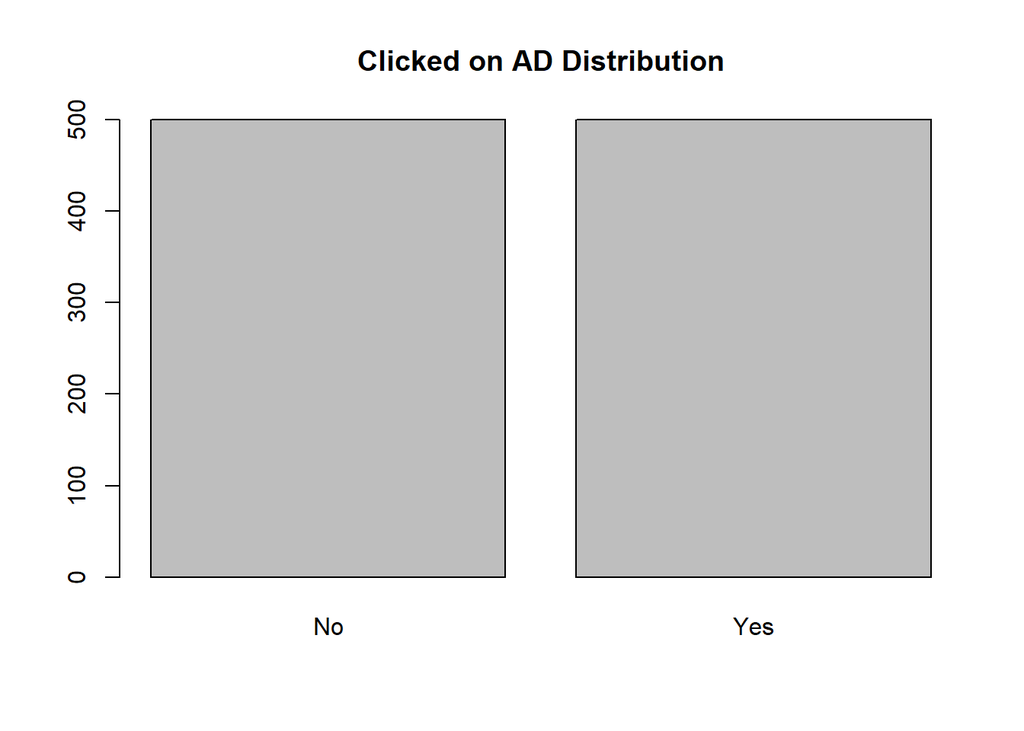

```r
Clicked.on.Ad.frequency = table(Clicked.on.Ad)
label <- c("No","Yes")
barplot(Clicked.on.Ad.frequency,names.arg = label,main = "Clicked on AD Distribution")
```

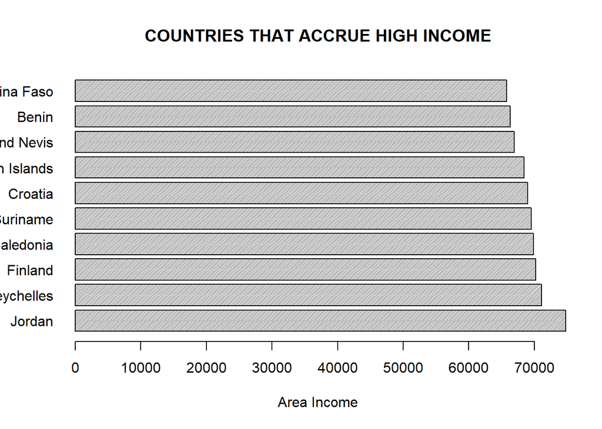

```r
# top 10 countries that accrue high average income
avg.country = aggregate(Income, by = list(Country), FUN = mean)
cou.top10 <- head(avg.country[order(avg.country$x,decreasing = TRUE), ],10)
barplot(cou.top10$x,main = "COUNTRIES THAT ACCRUE HIGH INCOME",
        xlab = "Area Income",
        density = 80,
        las = 1,
        names = cou.top10$Group.1,
        horiz = TRUE)
```

```r
# Creating a dataframe for those who clicked the ad
Ads <- advertising[Clicked.on.Ad == 1,]
```

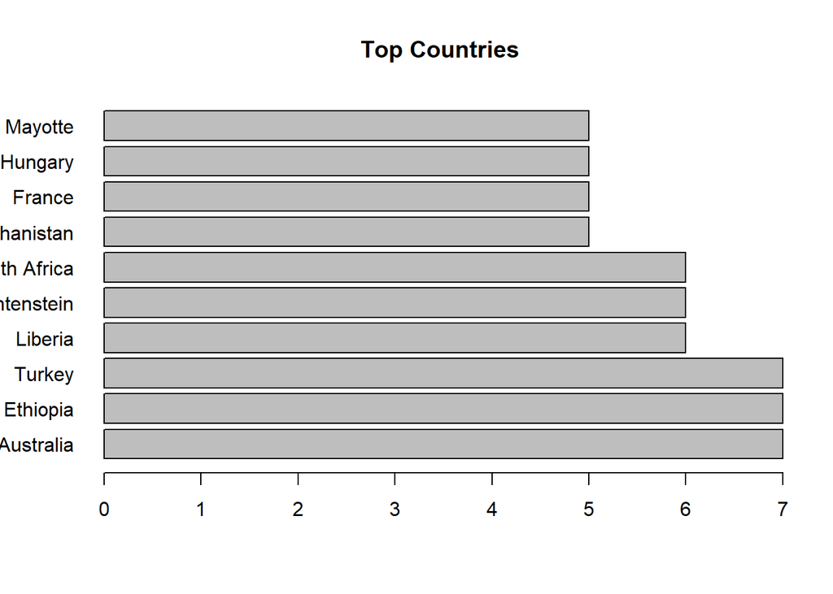

```r
## distribution for countries
topcountries<- head(sort(table(Ads$Country),decreasing=TRUE),n=10)
barplot(topcountries,las=1, main="Top Countries",horiz=TRUE)
```

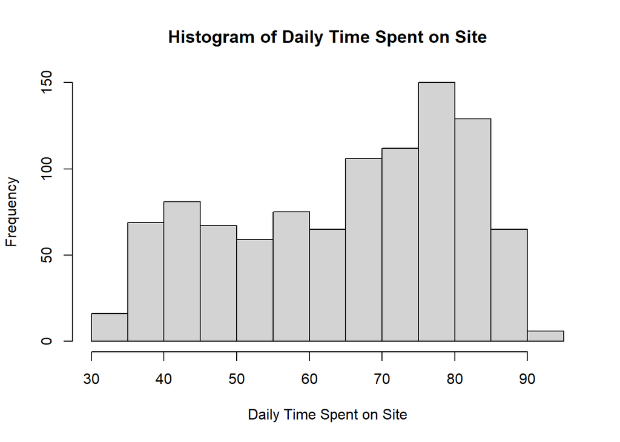

```r
hist(Time.onsite,xlab = "Daily Time Spent on Site", main = "Histogram of Daily Time Spent on Site")
```

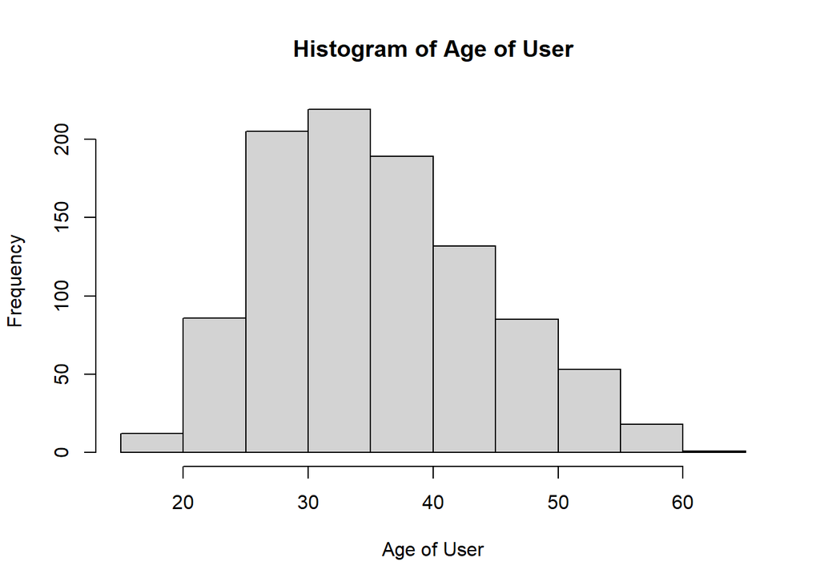

```r
hist(Age,xlab = "Age of User", main = "Histogram of Age of User")
```

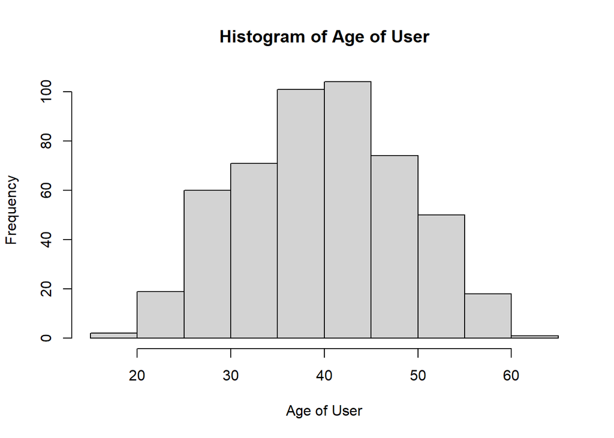

```r
hist(Ads$Age,xlab = "Age of User", main = "Histogram of Age of User")
```

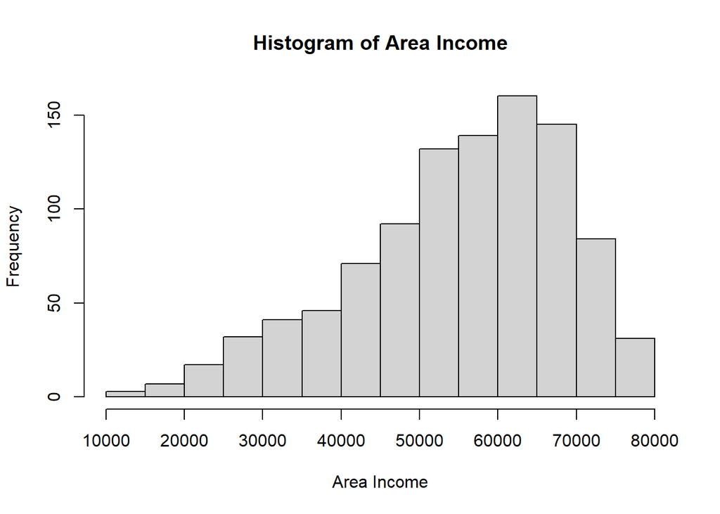

```r
hist(Income, xlab = "Area Income",main = "Histogram of Area Income")
```

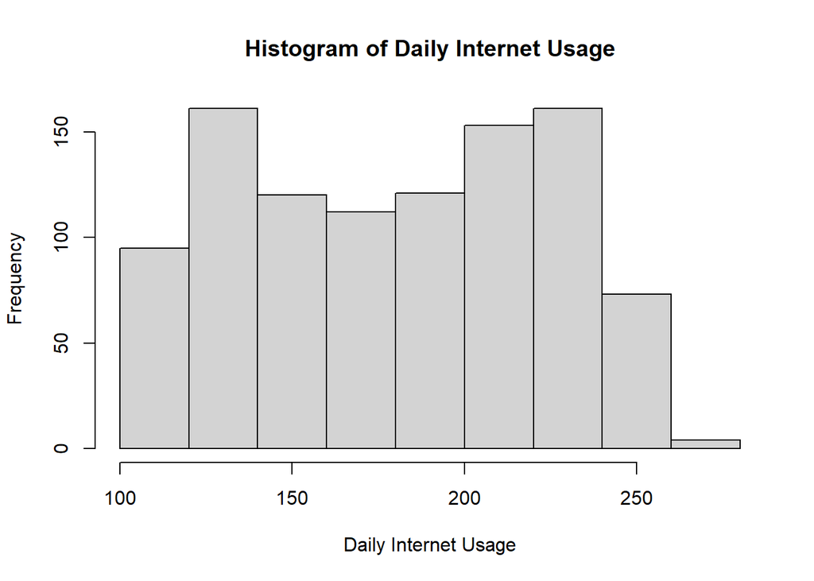

```r
hist(Internet,xlab = "Daily Internet Usage", main = "Histogram of Daily Internet Usage")
```

```r
library(psych)
```

```r
# Summary of measures of central tendency and dispersion
Description = describe(advertising)
Description
```

```
##                          vars    n     mean       sd   median  trimmed      mad
## Daily.Time.Spent.on.Site    1 1000    65.00    15.85    68.22    65.74    17.92
## Age                         2 1000    36.01     8.79    35.00    35.51     8.90
## Area.Income                 3 1000 55000.00 13414.63 57012.30 56038.94 13316.62
## Daily.Internet.Usage        4 1000   180.00    43.90   183.13   179.99    58.61
## Ad.Topic.Line*              5 1000   500.50   288.82   500.50   500.50   370.65
## City*                       6 1000   487.32   279.31   485.50   487.51   356.57
## Male                        7 1000     0.48     0.50     0.00     0.48     0.00
## Country*                    8 1000   116.41    69.94   114.50   115.82    89.70
## Timestamp*                  9 1000   500.50   288.82   500.50   500.50   370.65
## Clicked.on.Ad              10 1000     0.50     0.50     0.50     0.50     0.74
##                               min      max    range  skew kurtosis     se
## Daily.Time.Spent.on.Site    32.60    91.43    58.83 -0.37    -1.10   0.50
## Age                         19.00    61.00    42.00  0.48    -0.41   0.28
## Area.Income              13996.50 79484.80 65488.30 -0.65    -0.11 424.21
## Daily.Internet.Usage       104.78   269.96   165.18 -0.03    -1.28   1.39
## Ad.Topic.Line*               1.00  1000.00   999.00  0.00    -1.20   9.13
## City*                        1.00   969.00   968.00  0.00    -1.19   8.83
## Male                         0.00     1.00     1.00  0.08    -2.00   0.02
## Country*                     1.00   237.00   236.00  0.08    -1.23   2.21
## Timestamp*                   1.00  1000.00   999.00  0.00    -1.20   9.13
## Clicked.on.Ad                0.00     1.00     1.00  0.00    -2.00   0.02
```

## BIVARIATE ANALYSIS

```r
### Covariance between the Area_Income and Age and Clicked_on_Ad
cov(Income, Clicked.on.Ad)
```

```
## [1] -3195.989
```

```r
# Covariance between age and daily time on site
cov(Age,Time.onsite)
```

```
## [1] -46.17415
```

```r
### Covariance between the Age and Clicked on Ad
cov(Age,Clicked.on.Ad)
```

```
## [1] 2.164665
```

```r
## Covariance between the Age and Internet Usage
cov(Age,Internet)
```

```
## [1] -141.6348
```

```r
## Correlation between Age and Daily time onsite
cor(Age,Time.onsite)
```

```
## [1] -0.3315133
```

```r
## Correlation between age and internet
cor(Age, Internet)
```

```
## [1] -0.3672086
```

```r
#Plotting the above correlation matrix as a heatmap of whole dataset
#correlation
res <- cor(advertising[1:4],method = "pearson")
```

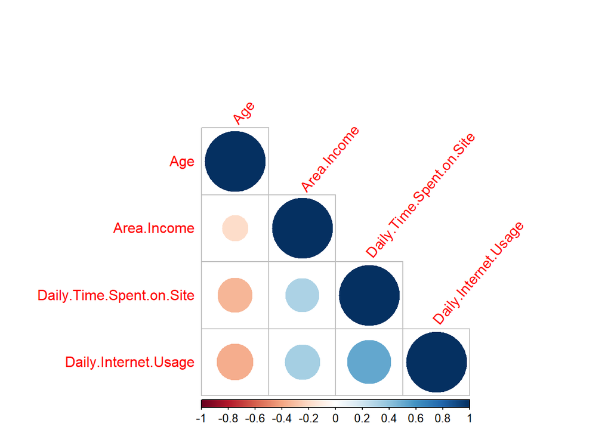

```r
#import library used to plot correlation matrix
library(corrplot)
## corrplot 0.84 loaded
corrplot(res, type = "lower", order = "hclust", tl.col = "red", tl.srt = 50)
```

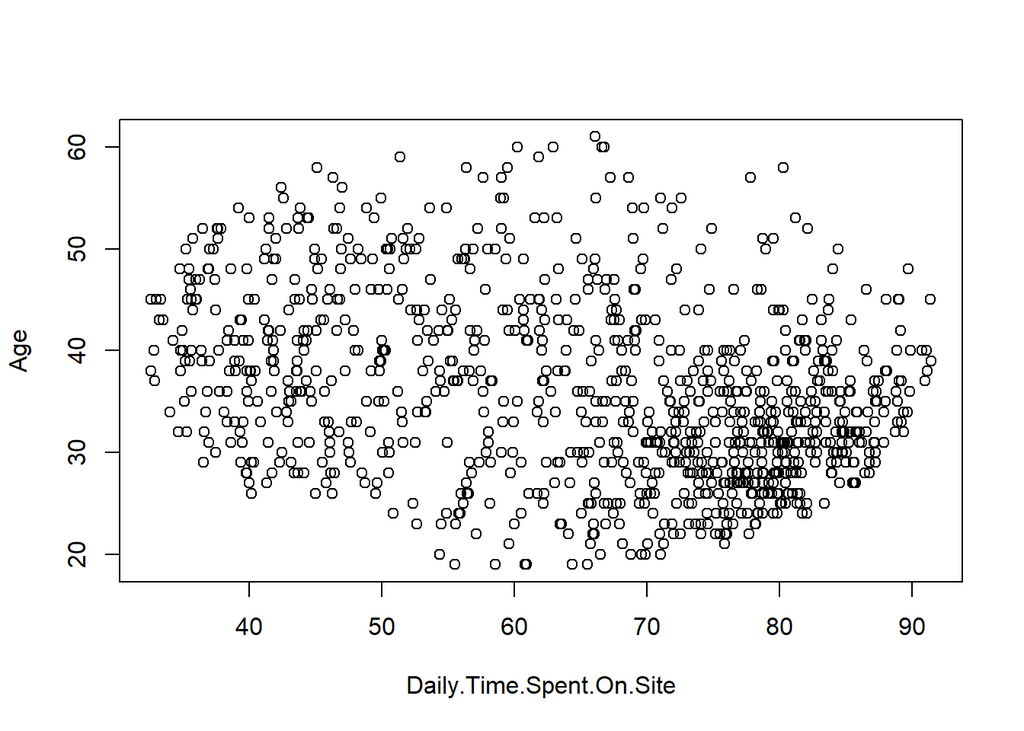

```r
plot(Time.onsite,Age, xlab ="Daily.Time.Spent.On.Site", ylab ="Age")
```

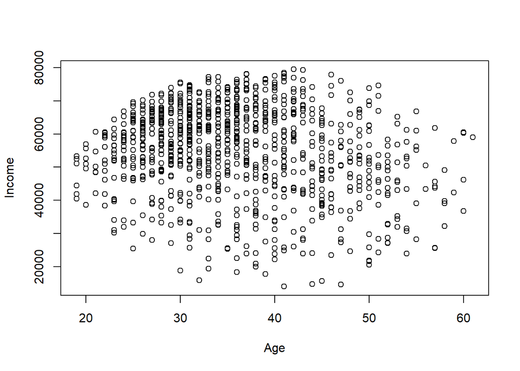

```r
plot(Age,Income, xlab ="Age", ylab ="Income")
```

## **IMPLEMENTING THE SOLUTION**

```r
# selecting numerical columns
df <- advertising[,c(1:4,7,10)]
head(df)
```

```
##   Daily.Time.Spent.on.Site Age Area.Income Daily.Internet.Usage Male
## 1                    68.95  35    61833.90               256.09    0
## 2                    80.23  31    68441.85               193.77    1
## 3                    69.47  26    59785.94               236.50    0
## 4                    74.15  29    54806.18               245.89    1
## 5                    68.37  35    73889.99               225.58    0
## 6                    59.99  23    59761.56               226.74    1
##   Clicked.on.Ad
## 1             0
## 2             0
## 3             0
## 4             0
## 5             0
## 6             0
```

```r
library(caTools)
# Splitting data into train
# and test data
split <- sample.split(df, SplitRatio = 0.8)
train <- subset(df, split == "TRUE")
test <- subset(df, split == "FALSE")

# Feature Scaling
train_scale <- scale(train[, 1:5])
test_scale <- scale(test[, 1:5])
```

### **LOGISTIC REGRESSION**

```r
Clicked.on.Ad <- train$Clicked.on.ad
Age <- train$Age
Internet <- train$Daily.Internet.Usage
Time.onsite <- train$Daily.Time.Spent.on.Site
Area.Income<- train$Area.Income
Gender <- train$Male
```

```r
model <- glm(Clicked.on.Ad ~ Age + Internet + Time.onsite + Area.Income + Gender, data=train, family = binomial(link = 'logit'))
```

```r
summary(model)
```

```
##
## Call:
## glm(formula = Clicked.on.Ad ~ Age + Internet + Time.onsite +
##     Area.Income + Gender, family = binomial(link = "logit"),
##     data = train)
##
## Deviance Residuals:
##     Min       1Q   Median       3Q      Max
## -2.5509  -0.1146  -0.0518   0.0140   3.2792
##
## Coefficients:
##               Estimate Std. Error z value Pr(>|z|)
## (Intercept)  2.895e+01  3.674e+00   7.880 3.29e-15 ***
## Age          1.547e-01  3.059e-02   5.058 4.24e-07 ***
## Internet    -7.077e-02  9.362e-03  -7.559 4.05e-14 ***
## Time.onsite -1.952e-01  2.722e-02  -7.170 7.52e-13 ***
## Area.Income -1.301e-04  2.339e-05  -5.564 2.64e-08 ***
## Gender      -5.876e-01  5.213e-01  -1.127     0.26
## ---
## Signif. codes:  0 '***' 0.001 '**' 0.01 '*' 0.05 '.' 0.1 ' ' 1
##
## (Dispersion parameter for binomial family taken to be 1)
##
##     Null deviance: 922.79  on 665  degrees of freedom
## Residual deviance: 110.87  on 660  degrees of freedom
## AIC: 122.87
##
## Number of Fisher Scoring iterations: 8
```

We run the anova() function on the model to analyze the table of deviance

```r
anova(model, test="Chisq")
```

```
## Analysis of Deviance Table
##
## Model: binomial, link: logit
##
## Response: Clicked.on.Ad
##
## Terms added sequentially (first to last)
##
##
##             Df Deviance Resid. Df Resid. Dev  Pr(>Chi)
## NULL                          665     922.79
## Age          1   155.18       664     767.61 < 2.2e-16 ***
## Internet     1   462.46       663     305.15 < 2.2e-16 ***
## Time.onsite  1   142.41       662     162.74 < 2.2e-16 ***
## Area.Income  1    50.58       661     112.16 1.144e-12 ***
## Gender       1     1.29       660     110.87    0.2559
## ---
## Signif. codes:  0 '***' 0.001 '**' 0.01 '*' 0.05 '.' 0.1 ' ' 1
```

[output not shown]

The difference between the null deviance and the residual deviance shows how our model is doing against the null model (a model with only the intercept). The wider this gap, the better. Analyzing the table we can see the drop in deviance when adding each variable one at a time. Again, adding Age, Internet and Time spent on site significantly reduces the residual deviance. The other variables seem to improve the model less. A large p-value here indicates that the model without the variable explains more or less the same amount of variation. Ultimately what you would like to see is a significant drop in deviance.

```r
library(pscl)
pR2(model)
```

```
## fitting null model for pseudo-r2
```

```
##          llh      llhNull           G2     McFadden         r2ML         r2CU
##  -55.4361709 -461.3927494  811.9131570    0.8798504    0.7045007    0.9395632
```

```r
Clicked.on.Ad <- test$Clicked.on.ad
Age <- test$Age
Internet <- test$Daily.Internet.Usage
Time.onsite <- test$Daily.Time.Spent.on.Site
Area.Income<- test$Area.Income
Gender <- test$Male
```

```r
fitted.results <- predict(model,newdata=subset(test,select=c(1:6)),type='response')
fitted.results <- ifelse(fitted.results > 0.5,1,0)
misClasificError <- mean(fitted.results != test$Clicked.on.Ad)
print(paste('Accuracy',1-misClasificError))
```

```
## [1] "Accuracy 0.976047904191617"
```

The 0.98 accuracy on the test set is quite a good result. However, keep in mind that this result is somewhat dependent on the manual split of the data made earlier, therefore if you wish for a more precise score, you would be better off running some kind of cross validation such as k-fold cross validation.

### **K-NEAREST NEIGHBOUR CLASSIFIER**

```r
library(class)
library(caret)
# Fitting KNN Model
# to training dataset
knn <- knn(train = train_scale,
           test = test_scale,
            cl = train$Clicked.on.Ad,
            k = 32)
```

```r
# Confusion Matrix
cm <- table(test$Clicked.on.Ad,knn)
confusionMatrix(cm)
```

```
## Confusion Matrix and Statistics
##
##    knn
##       0   1
##   0 158   0
##   1  14 162
##
##                Accuracy : 0.9581
##                  95% CI : (0.9307, 0.9769)
##     No Information Rate : 0.515
##     P-Value [Acc > NIR] : < 2.2e-16
##
##                   Kappa : 0.9163
##
##  Mcnemar's Test P-Value : 0.000512
##
##             Sensitivity : 0.9186
##             Specificity : 1.0000
##          Pos Pred Value : 1.0000
##          Neg Pred Value : 0.9205
##              Prevalence : 0.5150
##          Detection Rate : 0.4731
##    Detection Prevalence : 0.4731
##       Balanced Accuracy : 0.9593
##
##        'Positive' Class : 0
##
```

### **NAIVE BAYES CLASSIFIER**

```r
# Loading package
library(e1071)
library(caTools)
library(caret)
```

```r
# Fitting Naive Bayes Model to the training dataset
set.seed(120)  # Setting Seed
Naivebayes <- naiveBayes(Clicked.on.Ad ~ ., data = train)
```

```r
# Predicting on test data'
y_pred <- predict(Naivebayes, newdata = test)
# Confusion Matrix
cm <- table(test$Clicked.on.Ad,y_pred)

# Model Evauation
confusionMatrix(cm)
```

```
## Confusion Matrix and Statistics
##
##    y_pred
##       0   1
##   0 156   2
##   1   8 168
##
##                Accuracy : 0.9701
##                  95% CI : (0.9456, 0.9856)
##     No Information Rate : 0.509
##     P-Value [Acc > NIR] : <2e-16
##
##                   Kappa : 0.9401
##
##  Mcnemar's Test P-Value : 0.1138
##
##             Sensitivity : 0.9512
##             Specificity : 0.9882
##          Pos Pred Value : 0.9873
##          Neg Pred Value : 0.9545
##              Prevalence : 0.4910
##          Detection Rate : 0.4671
##    Detection Prevalence : 0.4731
##       Balanced Accuracy : 0.9697
##
##        'Positive' Class : 0
##
```

### **RANDOM FOREST CLASSIFIER**

```r
# Loading package
library(caTools)
library(randomForest)
# Fitting Random Forest to the train dataset
set.seed(120)  # Setting seed
rf <- randomForest(as.factor(Clicked.on.Ad) ~ .,
                        data = train,
                        importance = TRUE,
                        proximity = TRUE)
```

```r
print(rf)
```

```
##
## Call:
##  randomForest(formula = as.factor(Clicked.on.Ad) ~ ., data = train,      importance = TRUE, proximity = TRUE)
##                Type of random forest: classification
##                      Number of trees: 500
## No. of variables tried at each split: 2
##
##         OOB estimate of  error rate: 3.75%
## Confusion matrix:
##     0   1 class.error
## 0 331  11  0.03216374
## 1  14 310  0.04320988
```

```r
# Predicting the Test set results
y_pred = predict(rf, test)
```

```r
# Confusion Matrix
confusion_mtx = table( y_pred,test[, 6])
confusion_mtx
```

```
##
## y_pred   0   1
##      0 152   7
##      1   6 169
```

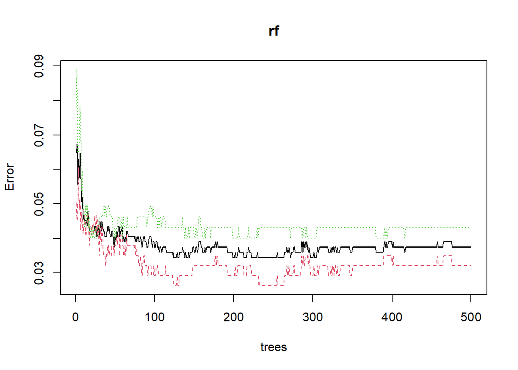

```r
# Plotting model
plot(rf)
```

```r
# Importance plot
importance(rf)
```

```
##                                  0           1 MeanDecreaseAccuracy
## Daily.Time.Spent.on.Site 74.977613 41.30778945            81.415653
## Age                      29.436008 10.12148235            28.438664
## Area.Income              30.317580 12.95249437            31.128469
## Daily.Internet.Usage     96.752546 51.41385495           104.854293
## Male                      3.691024 -0.03262095             2.848764
##                          MeanDecreaseGini
## Daily.Time.Spent.on.Site       115.770182
## Age                             26.531677
## Area.Income                     37.223306
## Daily.Internet.Usage           151.066426
## Male                             1.650131
```

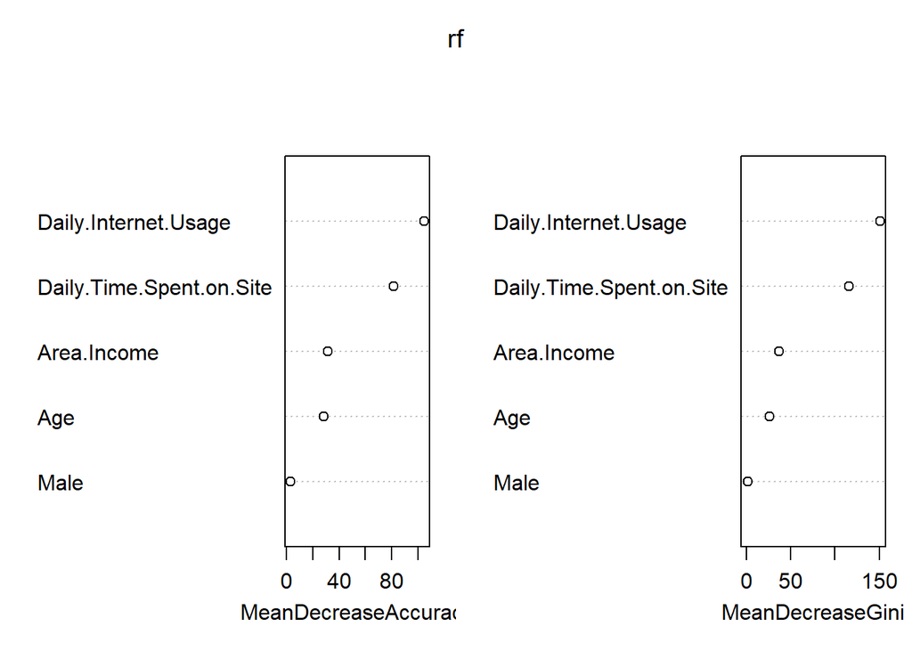

```r
# Variable importance plot
varImpPlot(rf)
```

As can be seen according to Random Forest Classifier the most important feature in our model is daily internet usage followed by daily time spent on site. The least important faeture is Gender.

## **Challenging the Solution**

To challenge our solution we try modelling using the support vectors classifier.

### **SUPPORT VECTOR CLASSIFIER**

```r
#
library(e1071)

classifier = svm(formula = Clicked.on.Ad ~ .,
                 data = train,
                 type = 'C-classification',
                 kernel = 'linear')
```

```r
# Predicting the Test set results
y_pred = predict(classifier, newdata = test[-6])
```

```r
# Making the Confusion Matrix
cm = table(test[, 6], y_pred)
cm
```

```
##    y_pred
##       0   1
##   0 157   1
##   1   9 167
```

```r
confusionMatrix(cm)
```

```
## Confusion Matrix and Statistics
##
##    y_pred
##       0   1
##   0 157   1
##   1   9 167
##
##                Accuracy : 0.9701
##                  95% CI : (0.9456, 0.9856)
##     No Information Rate : 0.503
##     P-Value [Acc > NIR] : < 2e-16
##
##                   Kappa : 0.9401
##
##  Mcnemar's Test P-Value : 0.02686
##
##             Sensitivity : 0.9458
##             Specificity : 0.9940
##          Pos Pred Value : 0.9937
##          Neg Pred Value : 0.9489
##              Prevalence : 0.4970
##          Detection Rate : 0.4701
##    Detection Prevalence : 0.4731
##       Balanced Accuracy : 0.9699
##
##        'Positive' Class : 0
##
```

## **RECOMMENDATIONS**

The most suitable models for prediction are Logistic regression, Naive Bayes Classifier and Support Vector Classifier Since they achieve the highest accuracies.

## **Follow up questions**

a). Did we have the right data? Yes, we had the right Data because the relevant independent variables have a high accuracy in predicting our dependent variable

b). Do we need other data to answer our question? Yes, we need more Data to ensure we haven’t over fitted our data.

c). Did we have the right question? Yes, we have the right question.